### Студент: Калугина Дарья

### Группа: РИ-450004

# Домашнее задание № 1

## Работа с данными.

По адресу http://people.math.umass.edu/~anna/Stat597AFall2016/rnf6080.dat можно получить набор данных об осадках в Канаде с 1960 по 1980 годы. Необходимо загрузить эти данные при помощи `read.table`. Воспользуйтесь справкой, чтобы изучить аргументы, которые принимает функция. - Загрузите данные в датафрейм, который назовите `data.df`

```r
data.df <- read.table(file = "http://people.math.umass.edu/~anna/Stat597AFall2016/rnf6080.dat")
```

- Сколько строк и столбцов в `data.df`? Если получилось не 5070 наблюдений 27 переменных, то проверяйте аргументы.

Полученный датафрейм имеет 5070 строк и 27 столбцов.

- Получите имена колонок из `data.df`.

```r
options(width = 4000)
data.df_names <- names(data.df) # получить имена переменных, входящих в таблицу данных
data.df_names
```

```
##  [1] "V1"  "V2"  "V3"  "V4"  "V5"  "V6"  "V7"  "V8"  "V9"  "V10" "V11" "V12" "V13" "V14" "V15" "V16" "V17" "V18" "V19" "V20" "V21" "V22" "V23" "V24" "V25" "V26" "V27"
```

- Найдите значение из 5 строки седьмого столбца.

```r
# два способа:
data.df[[7]][5]
```

```
## [1] 0
```

```r
data.df[5,7]
```

```
## [1] 0
```

- Напечатайте целиком 2 строку из `data.df`

```r
data.df[2,]
```

```
##   V1 V2 V3 V4 V5 V6 V7 V8 V9 V10 V11 V12 V13 V14 V15 V16 V17 V18 V19 V20 V21 V22 V23 V24 V25 V26 V27
## 2 60  4  2  0  0  0  0  0  0   0   0   0   0   0   0   0   0   0   0   0   0   0   0   0   0   0   0
```

- Объясните, что делает следующая строка кода `names(data.df) <- c("year", "month", "day", seq(0,23))`. Воспользуйтесь функциями `head` и `tail`, чтобы просмотреть таблицу. Что представляют собой последние 24 колонки?

```r
names(data.df) <- c("year", "month", "day", seq(0,23))
```

Данная строка кода назначает колонкам таблицы (т.е. переменным, для которых проводились измерения) новые имена “year”, “month,”day“,”0“,”1" и т.д. вместо “V1”, “V2”, “V3” и т.д.

```r
head(data.df, n=5) # просмотр первых пяти значений каждой переменной, входящей в таблицу
```

```
##   year month day 0 1 2 3 4 5 6 7 8 9 10 11 12 13 14 15 16 17 18 19 20 21 22 23
## 1   60     4   1 0 0 0 0 0 0 0 0 0 0  0  0  0  0  0  0  0  0  0  0  0  0  0  0
## 2   60     4   2 0 0 0 0 0 0 0 0 0 0  0  0  0  0  0  0  0  0  0  0  0  0  0  0
## 3   60     4   3 0 0 0 0 0 0 0 0 0 0  0  0  0  0  0  0  0  0  0  0  0  0  0  0
## 4   60     4   4 0 0 0 0 0 0 0 0 0 0  0  0  0  0  0  0  0  0  0  0  0  0  0  0
## 5   60     4   5 0 0 0 0 0 0 0 0 0 0  0  0  0  0  0  0  0  0  0  0  0  0  0  0
```

```r
tail(data.df, n=10) # просмотр последних 10 значений каждой переменной, входящей в таблицу
```

```
##      year month day 0 1 2 3 4 5 6 7 8 9 10 11 12 13 14 15 16 17 18 19 20 21 22 23
## 5061   80    11  21 0 0 0 0 0 0 0 0 0 0  0  0  0  0  0  0  0  0  0  0  0  0  0  0
## 5062   80    11  22 0 0 0 0 0 0 0 0 0 0  0  0  0  0  0  0  0  0  0  0  0  0  0  0
## 5063   80    11  23 0 0 0 0 0 0 0 0 0 0  0  0  0  0  0  0  0  0  0  0  0  0  0  0
## 5064   80    11  24 0 0 0 0 0 0 0 0 0 0  0  0  0  0  0  0  0  0  0  0  0  0  0  0
## 5065   80    11  25 0 0 0 0 0 0 0 0 0 0  0  0  0  0  0  0  0  0  0  0  0  0  0  0
## 5066   80    11  26 0 0 0 0 0 0 0 0 0 0  0  0  0  0  0  0  0  0  0  0  0  0  0  0
## 5067   80    11  27 0 0 0 0 0 0 0 0 0 0  0  0  0  0  0  0  0  0  0  0  0  0  0  0
## 5068   80    11  28 0 0 0 0 0 0 0 0 0 0  0  0  0  0  0  0  0  0  0  0  0  0  0  0
## 5069   80    11  29 0 0 0 0 0 0 0 0 0 0  0  0  0  0  0  0  0  0  0  0  0  0  0  0
## 5070   80    11  30 0 0 0 0 0 0 0 0 0 0  0  0  0  0  0  0  0  0  0  0  0  0  0  0
```

В последних 24 колонках датафрейма содержится информация о количестве осадков за каждый час в течение суток (каждая строка таблицы соответствует одному дню).

- Добавьте новую колонку с названием *daily*, в которую запишите сумму крайних правых 24 колонок. Постройте гистограмму по этой колонке. Какие выводы можно сделать?

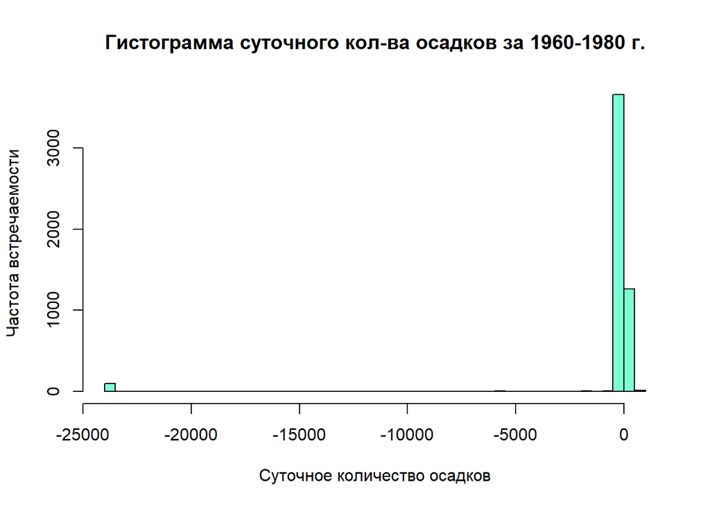

```r
data.df$daily <- rowSums(data.df[,4:27])
hist(data.df$daily, xlab = "Суточное количество осадков", ylab = "Частота встречаемости", main = "Гистограмма суточного кол-ва осадков за 1960-1980 г.", freq = TRUE, col="aquamarine", breaks = 50)
```

Полученная гистограмма отображается некорректно. В столбце *daily* есть отрицательные значения, поскольку часть ячеек датафрейма содержит значения *-999*. Поэтому при суммировании получаются большие отрицательные значения.

- Создайте новый датафрейм `fixed.df` в котором исправьте замеченную ошибку. Постройте новую гистограмму, поясните почему она более корректна.

```r
fixed.df <- data.df
for (i in 1:nrow(fixed.df)){
  for (j in 1:ncol(fixed.df)){
    if (fixed.df[i,j]==-999)
      fixed.df[i,j]<-0
  }
}
fixed.df$daily <- rowSums(fixed.df[,4:27])
```

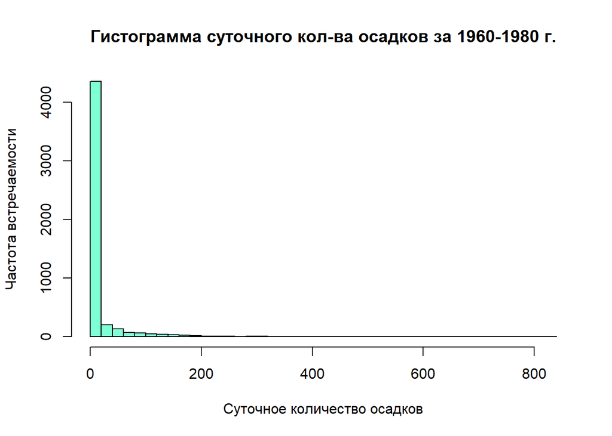

```r
hist(fixed.df$daily, xlab = "Суточное количество осадков", ylab = "Частота встречаемости", main = "Гистограмма суточного кол-ва осадков за 1960-1980 г.", freq = TRUE, col="aquamarine", breaks = 50)
```

Полученная выше гистограмма более корректна, т.к. она не отображает частоту встречаемости отрицательных значений количества осадков.

## Синтаксис и типизирование

- Для каждой строки кода поясните полученный результат, либо объясните почему она ошибочна.

```r
v <- c("4", "8", "15", "16", "23", "42")
max(v)
```

```
## [1] "8"
```

```r
sort(v)
```

```
## [1] "15" "16" "23" "4"  "42" "8"
```

```r
# sum(v)
```

Функции `max()` и`sort()` являются корректными в отношении векторов строк, т.к. могут принимать в качестве входных аргументов как числовые, так и строковые векторы. Строки при этом сортируются в лексикографическом порядке на основе ASCII-кодов символов.

Применение функции суммы для символьного вектора является ошибочным, поскольку функция `sum()` работает только с числовыми и логическими типами данных.

- Для следующих наборов команд поясните полученный результат, либо объясните почему они ошибочны.

```r
v2 <- c("5",7,12)
#v2[2] + v2[3]
```

Вектор представляет собой объект, содержащий набор однотипных элементов. Поэтому в данном случае значения *7* и *12* будут конвертированы в строковый тип данных. Строка кода `v2[2] + v2[3]` является ошибочной, т.к. вектор *v2* состоит из строк, а операция суммы к типу данных *character* неприменима:

```r
str(v2) # структура вектора
```

```
##  chr [1:3] "5" "7" "12"
```

```r
typeof(v2) # тип элементов вектора v2
```

```
## [1] "character"
```

```r
df3 <- data.frame(z1="5",z2=7,z3=12)
df3[1,2] + df3[1,3]
```

```
## [1] 19
```

В датафреймах (таблицах данных) колонки (переменные могут иметь разный тип данных). Из результата команды ``str(df3)` видно, что колонка *z1* состоит из данных номинального типа (текстовое значение *“5”* было конвертировано в фактор и пока в колонке присутствет только уровень *“5”*), а *z2* и *z3* являются числовыми. Следовательно, операция сложения применима к значениям из колонок *z2* и *z3*.

```r
df3
```

```
##   z1 z2 z3
## 1  5  7 12
```

```r
str(df3) # структура датафрейма
```

```
## 'data.frame':    1 obs. of  3 variables:
##  $ z1: Factor w/ 1 level "5": 1
##  $ z2: num 7
##  $ z3: num 12
```

```r
l4 <- list(z1="6", z2=42, z3="49", z4=126)
l4[[2]] + l4[[4]]
```

```
## [1] 168
```

```r
#l4[2] + l4[4]
```

Список представлет собой последовательность значений различного типа. Получать доступ к элементам вектора можно при помощи одинарных или двойных квадратных скобок. При выборе элементов списка одинарными квадратными скобками получаемый объект тоже будет списком, а при использовании двойных квадратных скобок объект будет того типа, каким он был до объединения в список. Поэтому в строке кода `l4[[2]] + l4[[4]]` будут складываться числовые значения, а строка `l4[2] + l4[4]` приведет к ошибке (т.к. невозможно сложить два списка).

## Работа с функциями и операторами

- Оператор двоеточие создаёт последовательность целых чисел по порядку. Этот оператор — частный случай функции `seq()`, которую вы использовали раньше. Изучите эту функцию, вызвав команду `?seq`. Испольуя полученные знания выведите на экран:
1. Числа от 1 до 10000 с инкрементом 372.

```r
seq.1 <- seq(from=1, to=10000, by=372)
print(seq.1) # полученная последовательность
```

```
##  [1]    1  373  745 1117 1489 1861 2233 2605 2977 3349 3721 4093 4465 4837 5209 5581 5953 6325 6697 7069 7441 7813 8185 8557 8929 9301 9673
```

```r
length(seq.1) # длина последовательности
```

```
## [1] 27
```

2. Числа от 1 до 10000 длиной 50.

```r
seq.2 <- seq(from=  1, to = 10000, length.out = 50)
print(seq.2) # полученная последовательность
```

[output not shown]

```r
length(seq.2) # длина последовательности
```

```
## [1] 50
```

- Функция `rep()` повторяет переданный вектор указанное число раз. Объясните разницу между `rep(1:5,times=3)` и `rep(1:5, each=3)`.

```r
rep(1:5,times=3)
```

```
##  [1] 1 2 3 4 5 1 2 3 4 5 1 2 3 4 5
```

```r
rep(1:5, each=3)
```

```
##  [1] 1 1 1 2 2 2 3 3 3 4 4 4 5 5 5
```

По умолчанию функция `rep()` повторяет переданный вектор один раз (*times=1*). Параметр *times* указывает, сколько раз нужно повторить *всю* последовательность, а параметр *each* - сколько раз нужно повторить сначала *первый* элемент последовательности, затем *второй* и т.д.